# R Code for Chapter 8 of Introduction to Data Mining: Clustering

Michael Hahsler

Wed Dec 14 11:31:40 2016

This code covers chapter 8 of *“Introduction to Data Mining”* by Pang-Ning Tan, Michael Steinbach and Vipin Kumar. **See [table of contents](https://github.com/mhahsler/Introduction_to_Data_Mining_R_Examples#readme) for code examples for other chapters.**

This work is licensed under the [Creative Commons Attribution 4.0 International License](http://creativecommons.org/licenses/by/4.0/). For questions please contact [Michael Hahsler](http://michael.hahsler.net).

```r
data(ruspini, package="cluster")
```

Shuffle rows

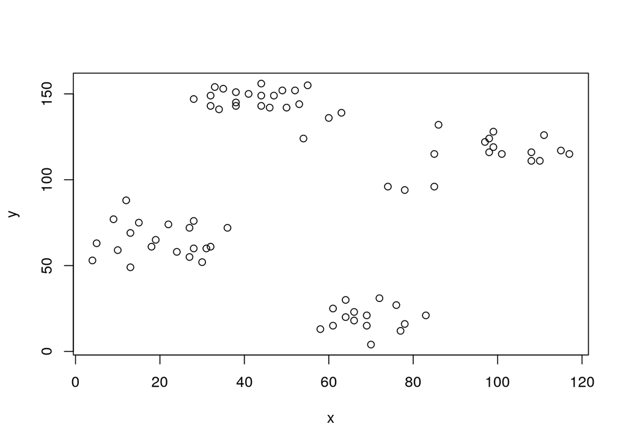

```r
ruspini <- ruspini[sample(1:nrow(ruspini)),]
plot(ruspini)
```

Scale each column in the data to zero mean and unit standard deviation (z-scores). This prevents one attribute with a large range to dominate the others for the distance calculation.

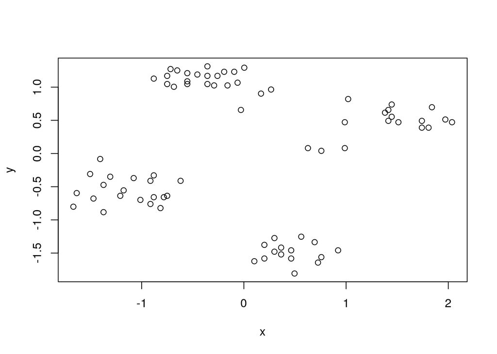

```r
ruspini_scaled <- scale(ruspini)
plot(ruspini_scaled)
```

# Clustering methods

## k-means Clustering

```r
km <- kmeans(ruspini_scaled, centers=4, nstart=10)
km
```

```
## K-means clustering with 4 clusters of sizes 15, 23, 20, 17
##
## Cluster means:
##            x          y
## 1  0.4607268 -1.4912271
## 2 -0.3595425  1.1091151
## 3 -1.1385941 -0.5559591
## 4  1.4194387  0.4692907
##
## Clustering vector:
## 63  2 34 10 60 71 36 12 75 55 26 65  6 51 42 46 74 19 30 20 15 67 32 70 66
##  1  3  2  3  4  1  2  3  1  4  2  1  3  4  2  4  1  3  2  3  3  1  2  1  1
## 68 47 13 57 33 62 44 27  1  3 43 54 35 16 69 11 21  9 14 37 41 17 28 72  5
##  1  4  3  4  2  1  4  2  3  3  2  4  2  3  1  3  2  3  3  2  2  3  2  1  3
## 52 61 22 73 58 25 53 56 48 23 31 38  4 59  8 64 18  7 50 45 24 29 39 40 49
##  4  1  2  1  4  2  4  4  4  2  2  2  3  4  3  1  3  3  4  4  2  2  2  2  4
##
## Within cluster sum of squares by cluster:
## [1] 1.082373 2.658679 2.705477 3.641276
##  (between_SS / total_SS =  93.2 %)
##
## Available components:
##
## [1] "cluster"      "centers"      "totss"        "withinss"
## [5] "tot.withinss" "betweenss"    "size"         "iter"
## [9] "ifault"
```

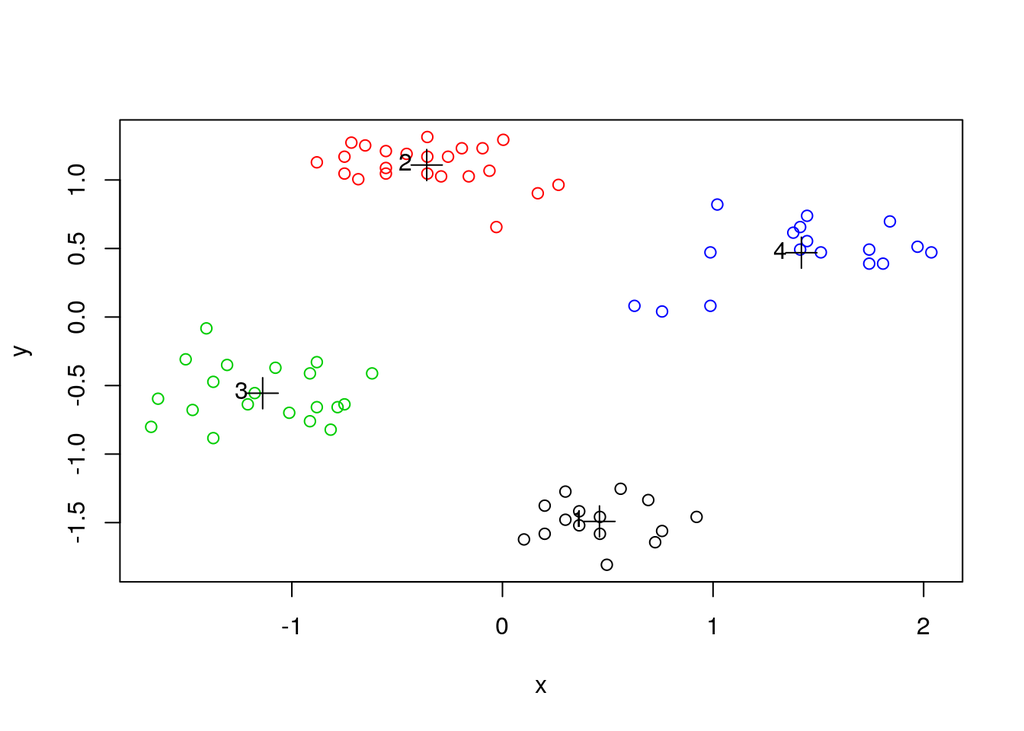

```r
plot(ruspini_scaled, col=km$cluster)
points(km$centers, pch=3, cex=2) # this adds the centroids
text(km$centers, labels=1:4, pos=2) # this adds the cluster ID
```

Alternative plot from package cluster (uses principal components analysis for >2 dimensions)

```r
library(cluster)
```

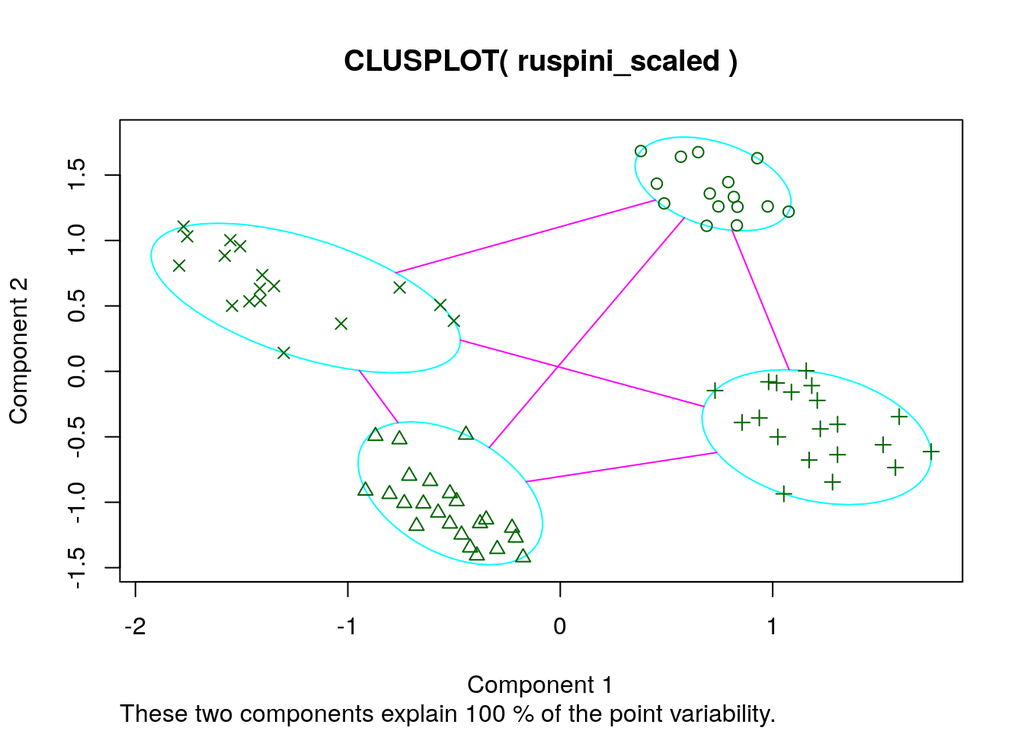

```r
clusplot(ruspini_scaled, km$cluster)
```

Inspect the centroids (cluster profiles)

```r
km$centers
```

```
##            x          y
## 1  0.4607268 -1.4912271
## 2 -0.3595425  1.1091151
## 3 -1.1385941 -0.5559591
## 4  1.4194387  0.4692907
```

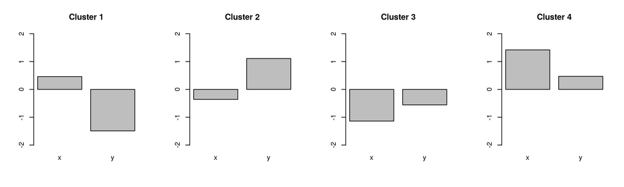

```r
def.par <- par(no.readonly = TRUE) # save default, for resetting...
layout(t(1:4)) # 4 plots in one
for(i in 1:4) barplot(km$centers[i,], ylim=c(-2,2), main=paste("Cluster", i))
```

```r
par(def.par)  #- reset to default
```

Find data for a single cluster

All you need is to select the rows corresponding to the cluster. The next example plots all data points of cluster 1

```r
cluster1 <- ruspini_scaled[km$cluster==1,]
head(cluster1)
```

```
##            x         y
## 63 0.9218907 -1.458375
## 71 0.3645599 -1.417309
## 75 0.2989916 -1.273580
## 65 0.4629124 -1.581571
## 74 0.5612649 -1.253047
## 67 0.3645599 -1.519973
```

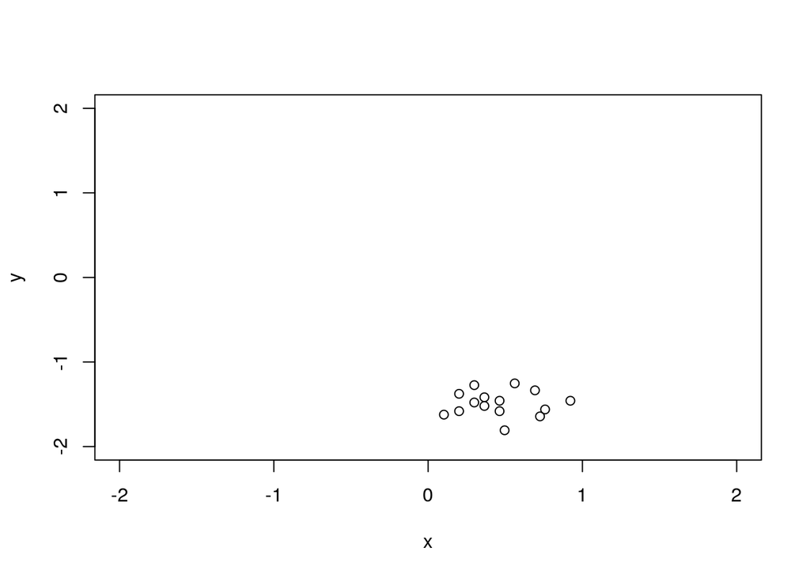

```r
plot(cluster1, xlim = c(-2,2), ylim = c(-2,2))
```

Try 10 clusters

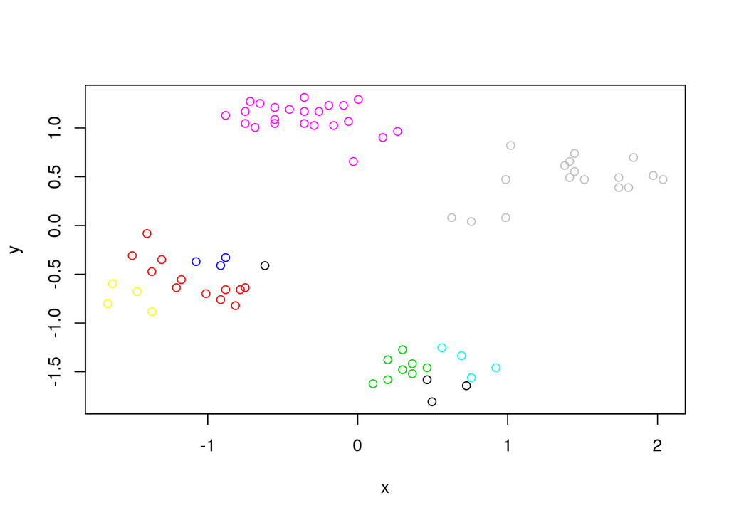

```r
plot(ruspini_scaled, col=kmeans(ruspini_scaled, centers=10)$cluster)
```

## Hierarchical Clustering

dist defaults to method=“Euclidean”

```r
d <- dist(ruspini_scaled)
```

We cluster using complete link

```r
hc <- hclust(d, method="complete")
```

Dendrogram

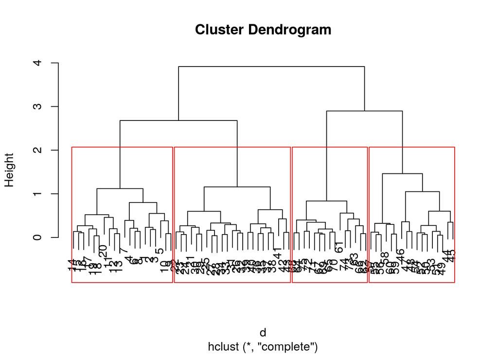

```r
plot(hc)
rect.hclust(hc, k=4)
```

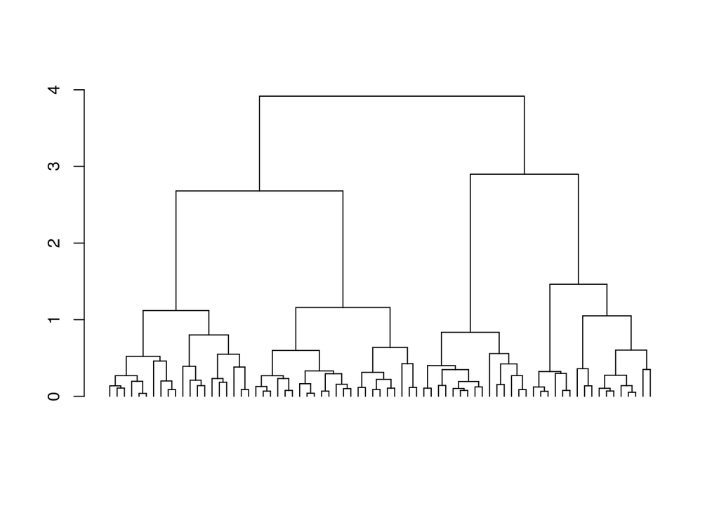

```r
plot(as.dendrogram(hc), leaflab="none") # plot dendrogram without leaf labels
```

More plotting options for dendrograms, including plotting parts of large dendrograms can be found [here.](https://rpubs.com/gaston/dendrograms)

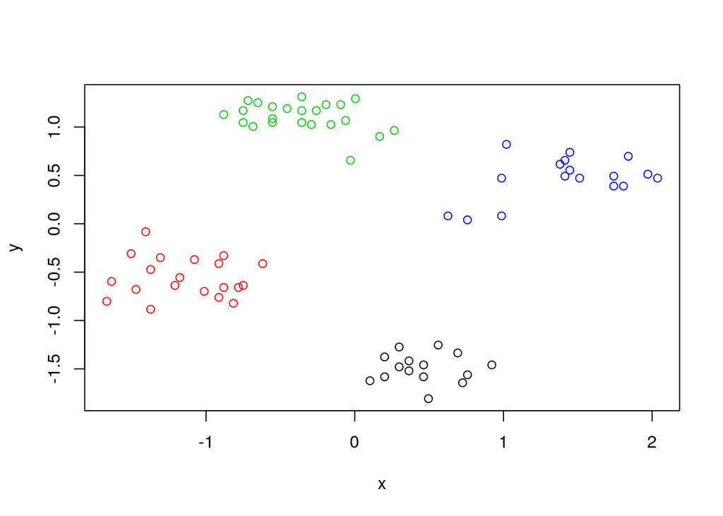

```r
cluster_complete <- cutree(hc, k=4)
plot(ruspini_scaled, col=cluster_complete)
```

Try 10 clusters

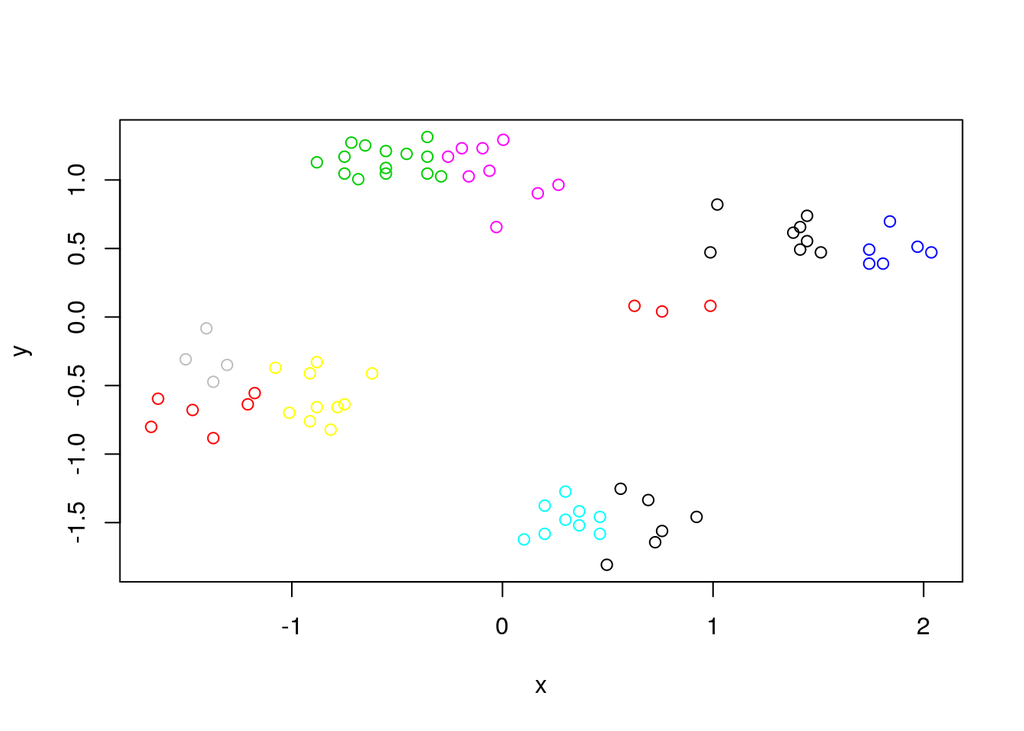

```r
plot(ruspini_scaled, col=cutree(hc, k=10))
```

Clustering with single link

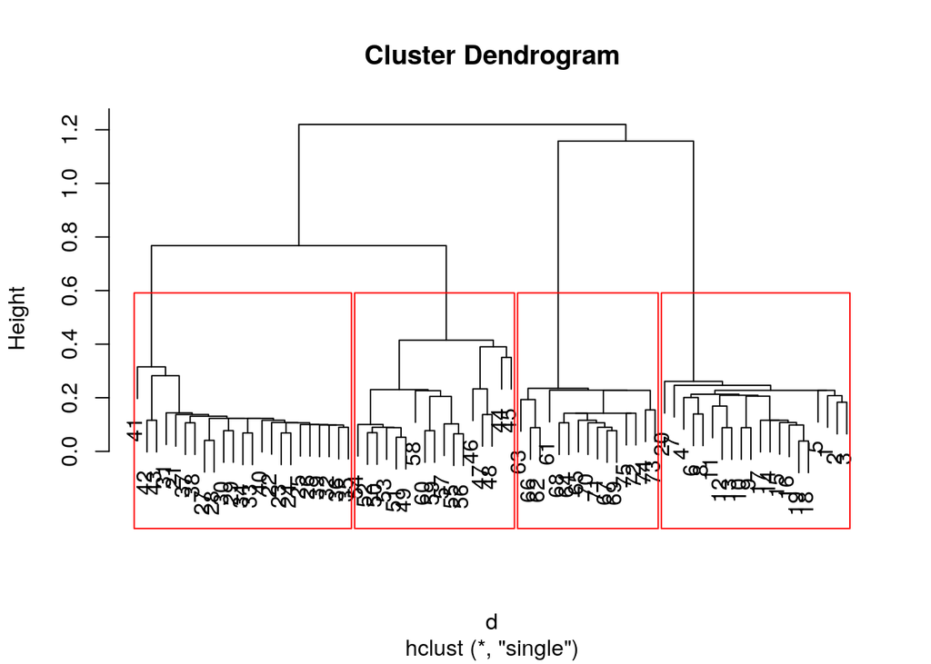

```r
hc_single <- hclust(d, method="single")
plot(hc_single)
rect.hclust(hc_single, k=4)
```

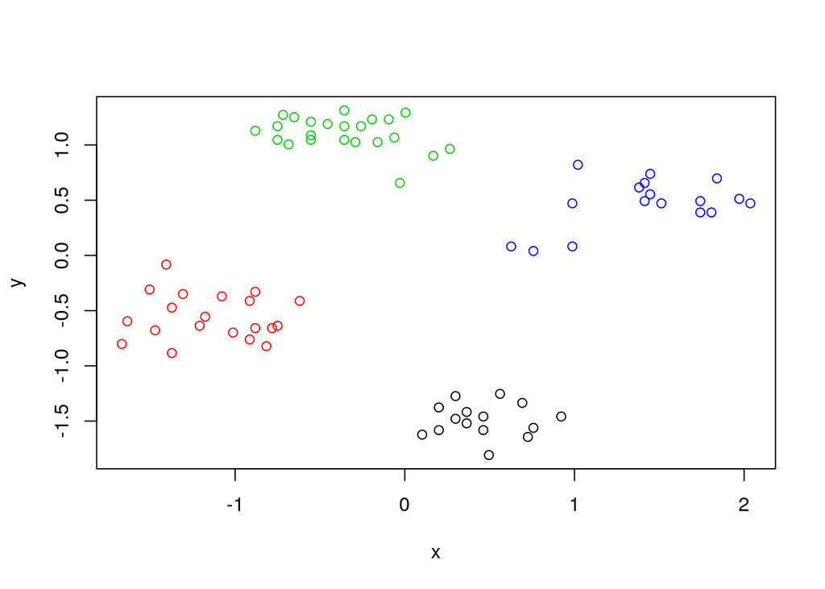

```r
cluster_single <- cutree(hc_single, k=4)
plot(ruspini_scaled, col=cluster_single)
```

Try 10 clusters

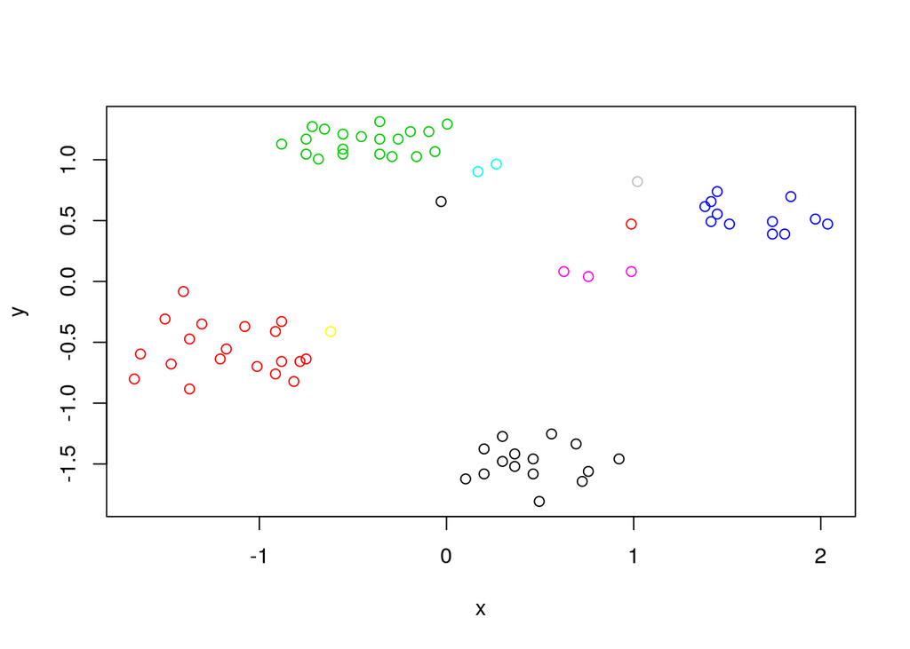

```r
plot(ruspini_scaled, col=cutree(hc_single, k=10))
```

## Density-based clustering with DBSCAN

```r
library(dbscan)
```

Parameters: minPts is often chosen as dimensionality of the data +1. Decide on epsilon using the knee in the kNN distance plot (seems to be around eps = .25).

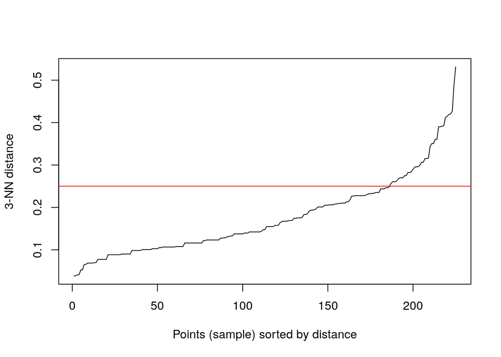

```r
kNNdistplot(ruspini_scaled, k = 3)
abline(h=.25, col="red")
```

run dbscan

```r
db <- dbscan(ruspini_scaled, eps=.25, minPts=3)
db
```

```
## DBSCAN clustering for 75 objects.
## Parameters: eps = 0.25, minPts = 3
## The clustering contains 5 cluster(s) and 6 noise points.
##
##  0  1  2  3  4  5
##  6 19 20 12 15  3
##
## Available fields: cluster, eps, minPts
```

```r
str(db)
```

```
## List of 3
##  $ cluster: int [1:75] 4 1 2 1 3 4 2 1 4 3 ...
##  $ eps    : num 0.25
##  $ minPts : num 3
##  - attr(*, "class")= chr [1:2] "dbscan_fast" "dbscan"
```

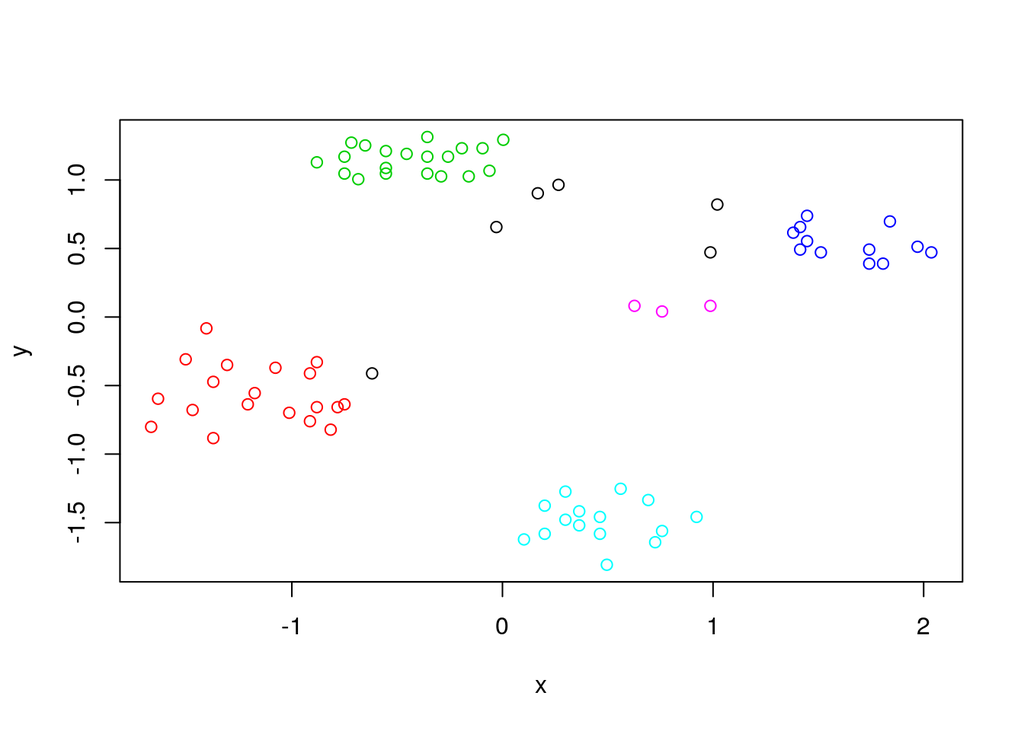

```r
plot(ruspini_scaled, col=db$cluster+1L)
```

**Note:** 0 is not a color so we add 1 to cluster (0 is black now).

Alternative visualization from package dbscan

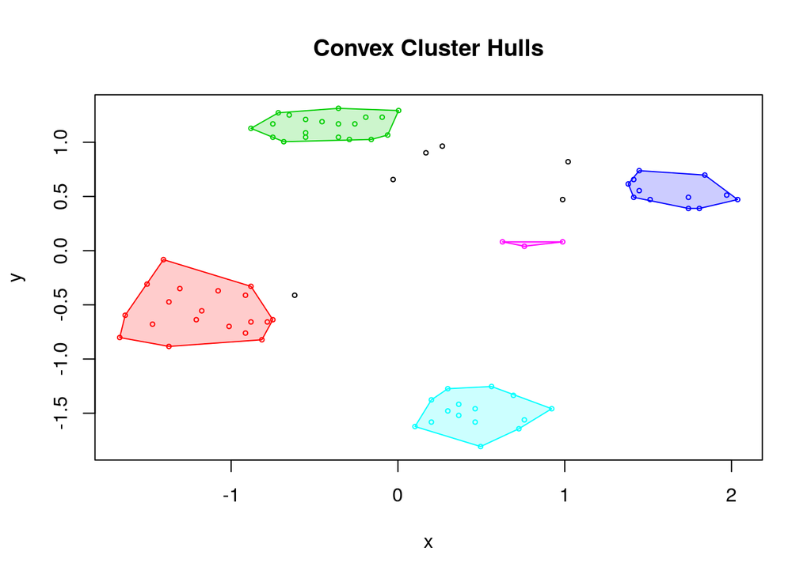

```r
hullplot(ruspini_scaled, db)
```

Play with eps (neighborhood size) and MinPts (minimum of points needed for core cluster)

## Gaussian Mixture Models

```r
library(mclust)
```

Mclust uses Bayesian Information Criterion (BIC) to find the number of clusters (model selection). BIC uses the likelihood and a penalty term to guard against overfitting.

```r
m <- Mclust(ruspini_scaled)
summary(m)
```

```
## ----------------------------------------------------
## Gaussian finite mixture model fitted by EM algorithm
## ----------------------------------------------------
##
## Mclust EEI (diagonal, equal volume and shape) model with 5 components:
##
##  log.likelihood  n df       BIC       ICL
##       -91.26485 75 16 -251.6095 -251.7486
##
## Clustering table:
##  1  2  3  4  5
## 15 20 23 14  3
```

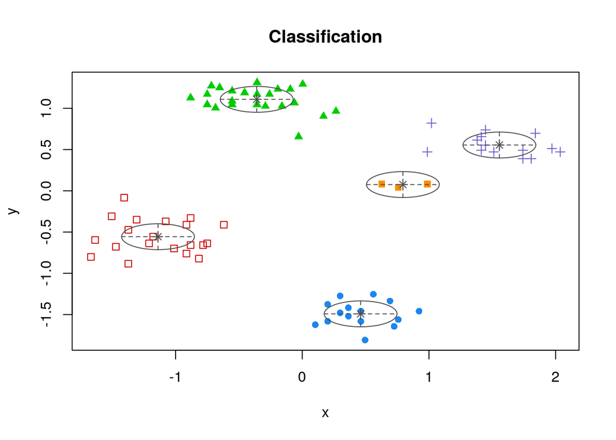

```r
plot(m, what = "classification")
```

Rerun with a fixed number of 4 clusters

```r
m <- Mclust(ruspini_scaled, G=4)
summary(m)
```

```
## ----------------------------------------------------
## Gaussian finite mixture model fitted by EM algorithm
## ----------------------------------------------------
##
## Mclust EEI (diagonal, equal volume and shape) model with 4 components:
##
##  log.likelihood  n df       BIC       ICL
##       -101.6027 75 13 -259.3327 -259.3356
##
## Clustering table:
##  1  2  3  4
## 15 20 23 17
```

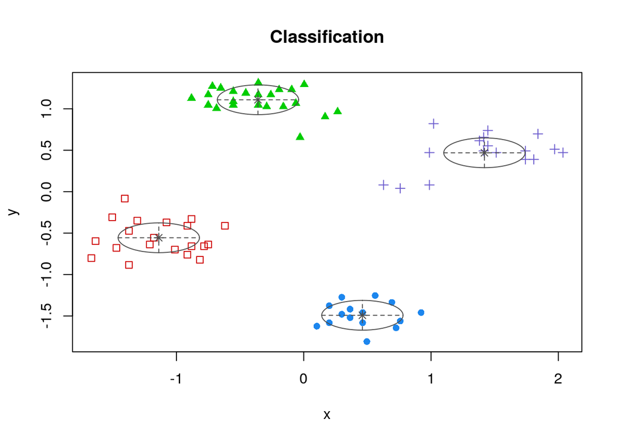

```r
plot(m, what = "classification")
```

## Spectral clustering

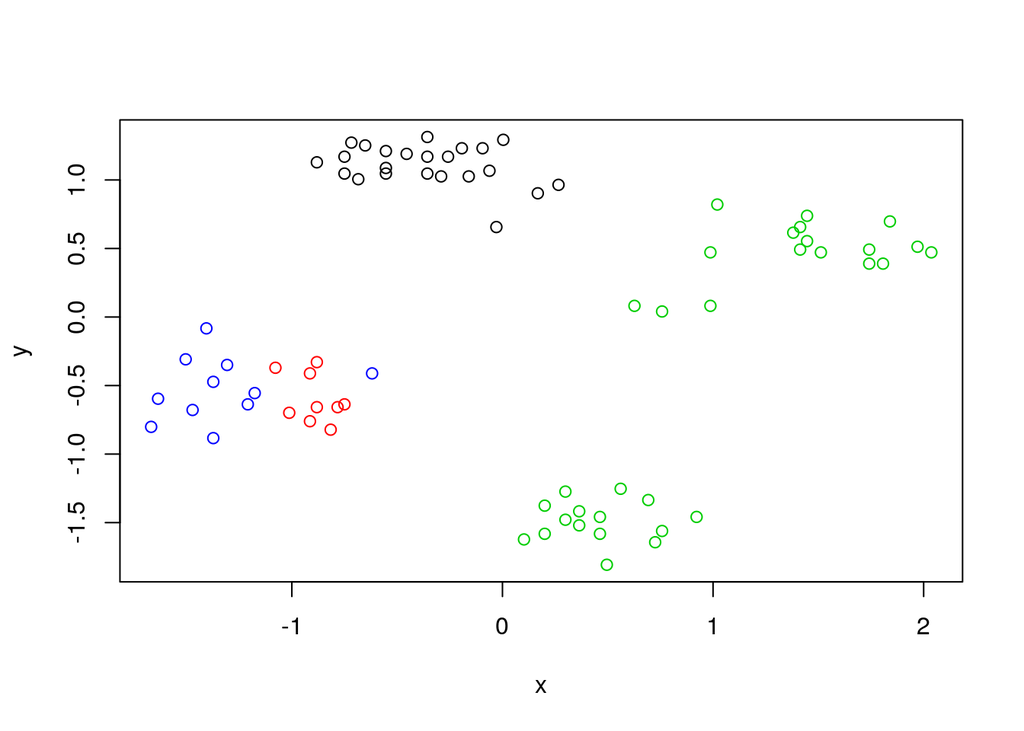

```r
library("kernlab")
cluster_spec <- specc(ruspini_scaled, centers = 4)

plot(ruspini_scaled, col=cluster_spec)
```

# Internal Cluster Validation

## Compare the Clustering Quality

Look at the within.cluster.ss and the avg.silwidth

```r
#library(fpc)
```

Note: I do not load fpc since the NAMESPACE overwrites dbscan.

```r
fpc::cluster.stats(d, km$cluster)
```

```
## $n
## [1] 75
##
## $cluster.number
## [1] 4
##
## $cluster.size
## [1] 15 23 20 17
##
## $min.cluster.size
## [1] 15
##
## $noisen
## [1] 0
##
## $diameter
## [1] 0.8359025 1.1591436 1.1192822 1.4627043
##
## $average.distance
## [1] 0.3564457 0.4286139 0.4824376 0.5805551
##
## $median.distance
## [1] 0.3379729 0.3934100 0.4492432 0.5023855
##
## $separation
## [1] 1.157682 0.767612 1.157682 0.767612
##
## $average.toother
## [1] 2.307969 2.148527 2.157193 2.293318
##
## $separation.matrix
##          [,1]     [,2]     [,3]     [,4]
## [1,] 0.000000 1.957726 1.157682 1.308435
## [2,] 1.957726 0.000000 1.219930 0.767612
## [3,] 1.157682 1.219930 0.000000 1.339721
## [4,] 1.308435 0.767612 1.339721 0.000000
##
## $ave.between.matrix
##          [,1]     [,2]     [,3]     [,4]
## [1,] 0.000000 2.750174 1.874198 2.220011
```

[output cut: 55 more lines]

```
##
## $cwidegap
## [1] 0.2351854 0.3152817 0.2611701 0.4149825
##
## $widestgap
## [1] 0.4149825
##
## $sindex
## [1] 0.8583457
##
## $corrected.rand
## NULL
##
## $vi
## NULL
```

```r
#cluster.stats(d, cluster_complete)
#cluster.stats(d, cluster_single)
```

Read `? cluster.stats` for an explanation of all the available indices.

```r
sapply(list(
  km=km$cluster,
  hc_compl=cluster_complete,
  hc_single=cluster_single),
       FUN=function(x)
         fpc::cluster.stats(d, x))[c("within.cluster.ss","avg.silwidth"),]
```

```
##                   km        hc_compl  hc_single
## within.cluster.ss 10.08781  10.08781  10.08781
## avg.silwidth      0.7368082 0.7368082 0.7368082
```

## Silhouette plot

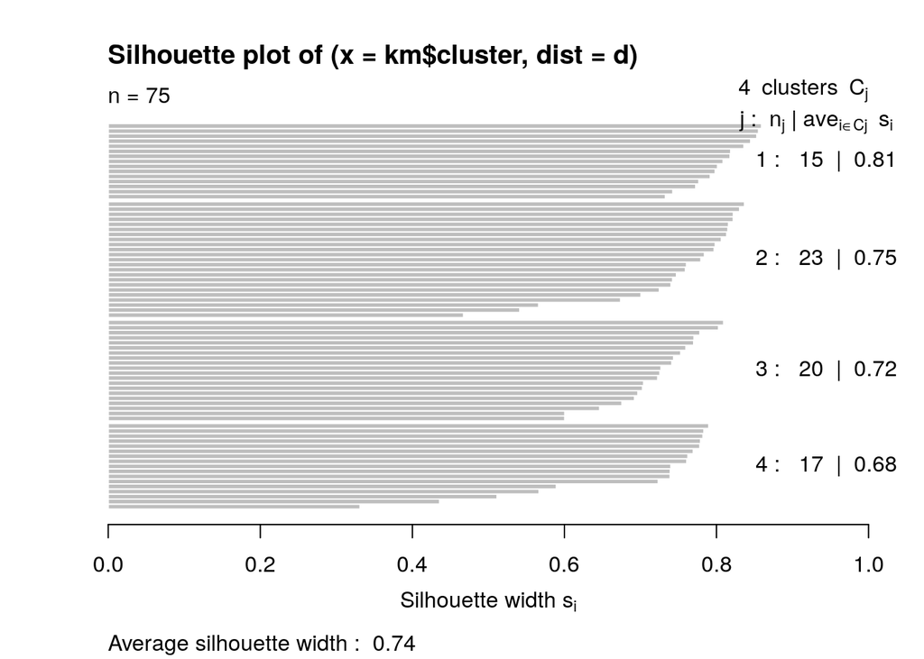

```r
plot(silhouette(km$cluster, d))
```

**Note:** The silhouette plot does not show correctly in R Studio if you have too many objects (bars are missing). I will work when you open a new plotting device with `windows()`, `x11()` or `quartz()`.

## Find Optimal Number of Clusters for k-means

```r
set.seed(1234)
ks <- 2:10
```

### Within Sum of Squares

Use within sum of squares and look for the knee (nstart=5 repeats k-means 5 times and returns the best solution)

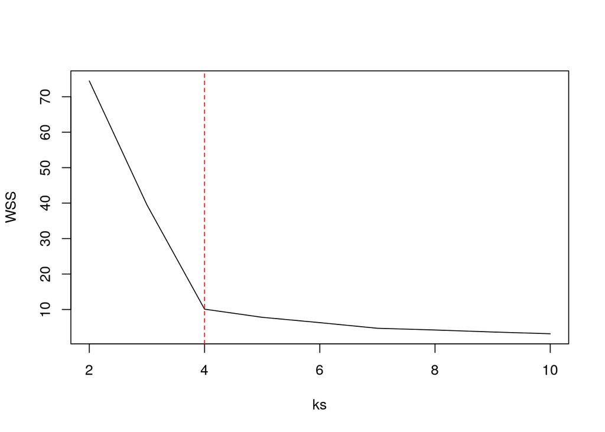

```r
WSS <- sapply(ks, FUN=function(k) {
  kmeans(ruspini_scaled, centers=k, nstart=5)$tot.withinss
  })
plot(ks, WSS, type="l")
abline(v=4, col="red", lty=2)
```

### Average Silhouette Width

Use average silhouette width (look for the max)

```r
ASW <- sapply(ks, FUN=function(k) {
  fpc::cluster.stats(d, kmeans(ruspini_scaled, centers=k, nstart=5)$cluster)$avg.silwidth
  })
plot(ks, ASW, type="l")

ks[which.max(ASW)]
```

```
## [1] 4
```

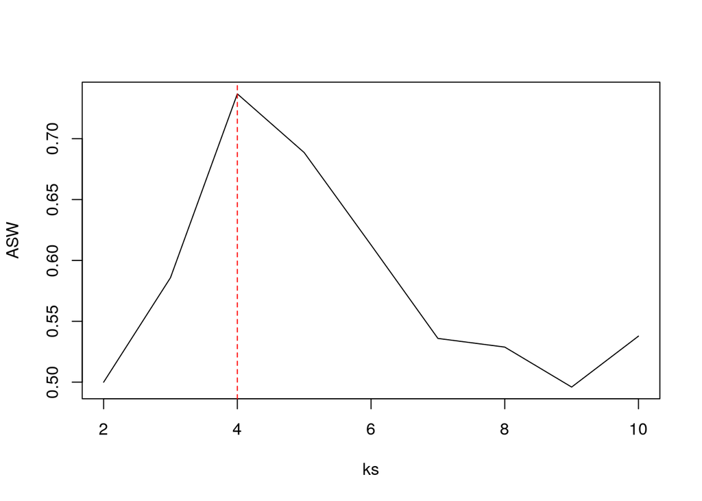

```r
abline(v=ks[which.max(ASW)], col="red", lty=2)
```

### Dunn Index

Use Dunn index (another internal measure given by min. separation/ max. diameter)

```r
DI <- sapply(ks, FUN=function(k) {
  fpc::cluster.stats(d, kmeans(ruspini_scaled, centers=k, nstart=5)$cluster)$dunn
})
plot(ks, DI, type="l")
ks[which.max(DI)]
```

```
## [1] 4
```

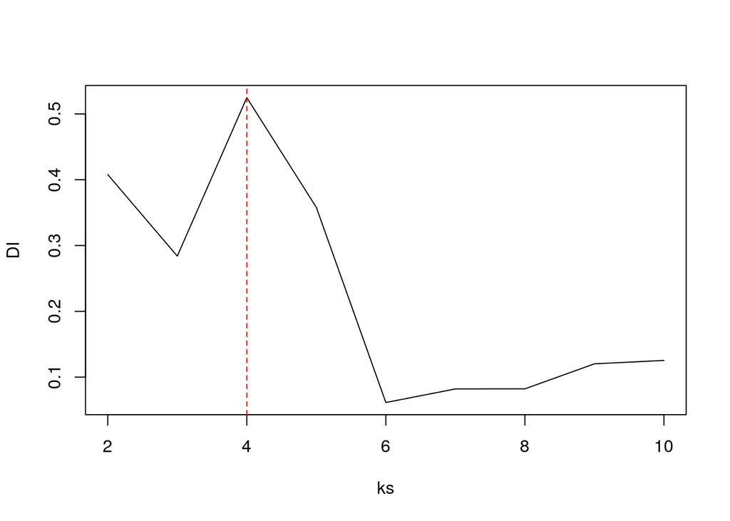

```r
abline(v=ks[which.max(DI)], col="red", lty=2)
```

### Gap Statistic

Compares the change in within-cluster dispersion with that expected from a null model (see `? clusGap`). The default method is to choose the smallest k such that its value Gap(k) is not more than 1 standard error away from the first local maximum.

```r
library(cluster)
k <- clusGap(ruspini_scaled, FUN = kmeans,  nstart = 10, K.max = 10)
k
```

```
## Clustering Gap statistic ["clusGap"] from call:
## clusGap(x = ruspini_scaled, FUNcluster = kmeans, K.max = 10,     nstart = 10)
## B=100 simulated reference sets, k = 1..10; spaceH0="scaledPCA"
##  --> Number of clusters (method 'firstSEmax', SE.factor=1): 4
##           logW   E.logW         gap     SE.sim
##  [1,] 3.497911 3.474301 -0.02360980 0.03835335
##  [2,] 3.073937 3.157027  0.08309024 0.04005118
##  [3,] 2.678004 2.908822  0.23081785 0.03767224
##  [4,] 2.106416 2.710845  0.60442835 0.03725234
##  [5,] 1.987213 2.571981  0.58476735 0.03699570
##  [6,] 1.863936 2.455285  0.59134824 0.03851437
##  [7,] 1.732234 2.350146  0.61791223 0.03754122
##  [8,] 1.640492 2.257624  0.61713194 0.03782124
##  [9,] 1.579299 2.172410  0.59311149 0.03841206
## [10,] 1.508038 2.094176  0.58613822 0.03782182
```

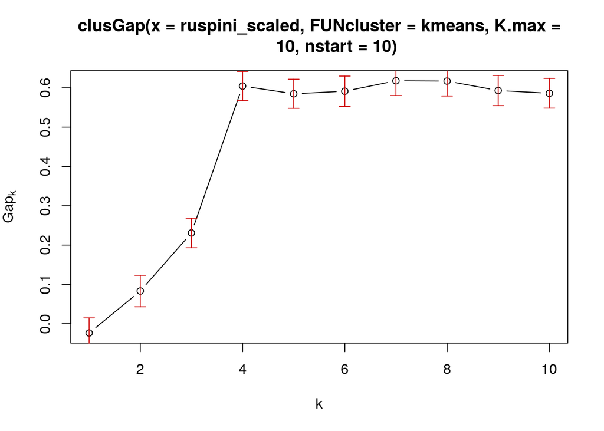

```r
plot(k)
```

**Note:** these methods can also be used for hierarchical clustering.

There have been many other methods and indices proposed to determine the number of clusters. See, e.g., package NbClust.

## Visualize the Distance Matrix

Visualizing the unordered distance matrix does not show much structure.

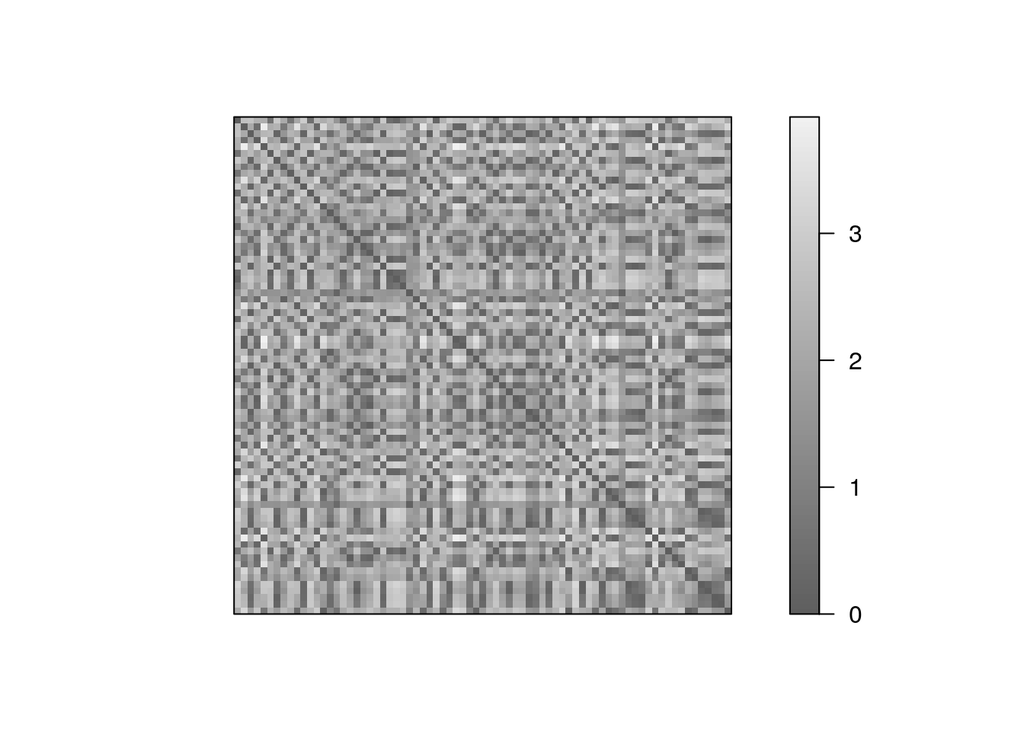

```r
library(seriation)
pimage(d, colorkey=TRUE)
```

Reorder using cluster labels

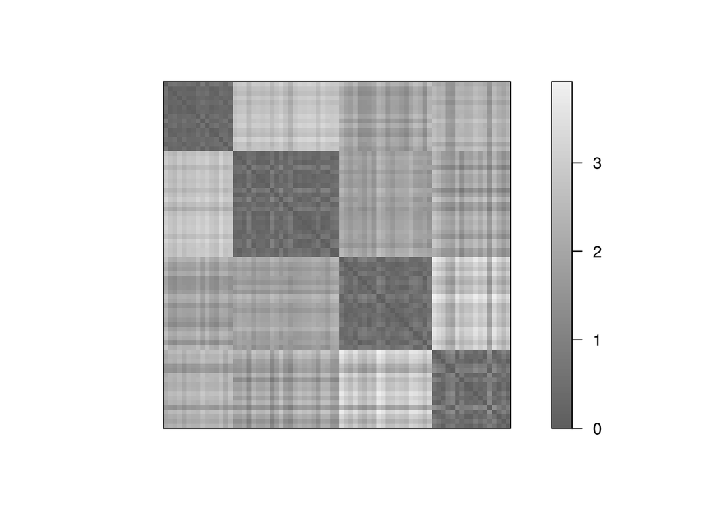

```r
pimage(d, order=order(km$cluster), colorkey=TRUE)
```

Use dissplot which rearranges clusters, adds cluster labels, and shows average dissimilarity in the lower half of the plot.

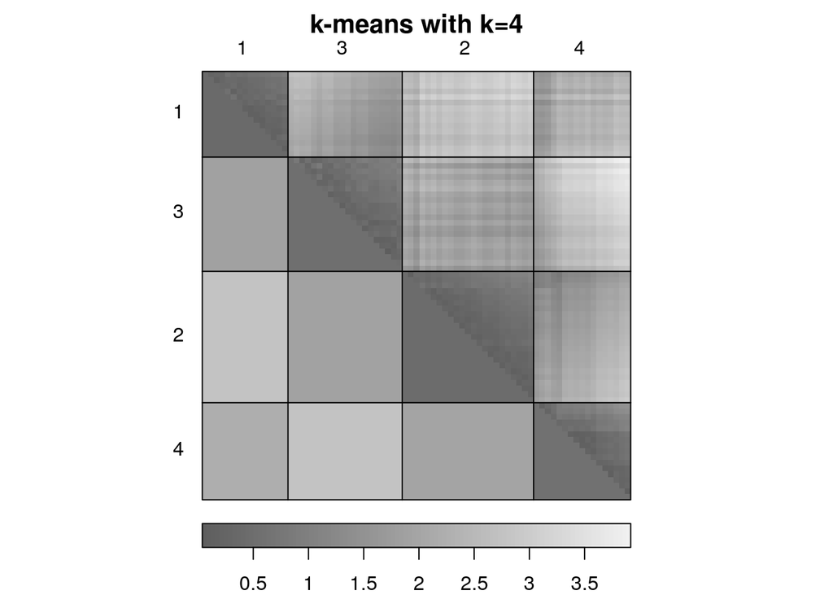

```r
dissplot(d, labels=km$cluster, options=list(main="k-means with k=4"))
```

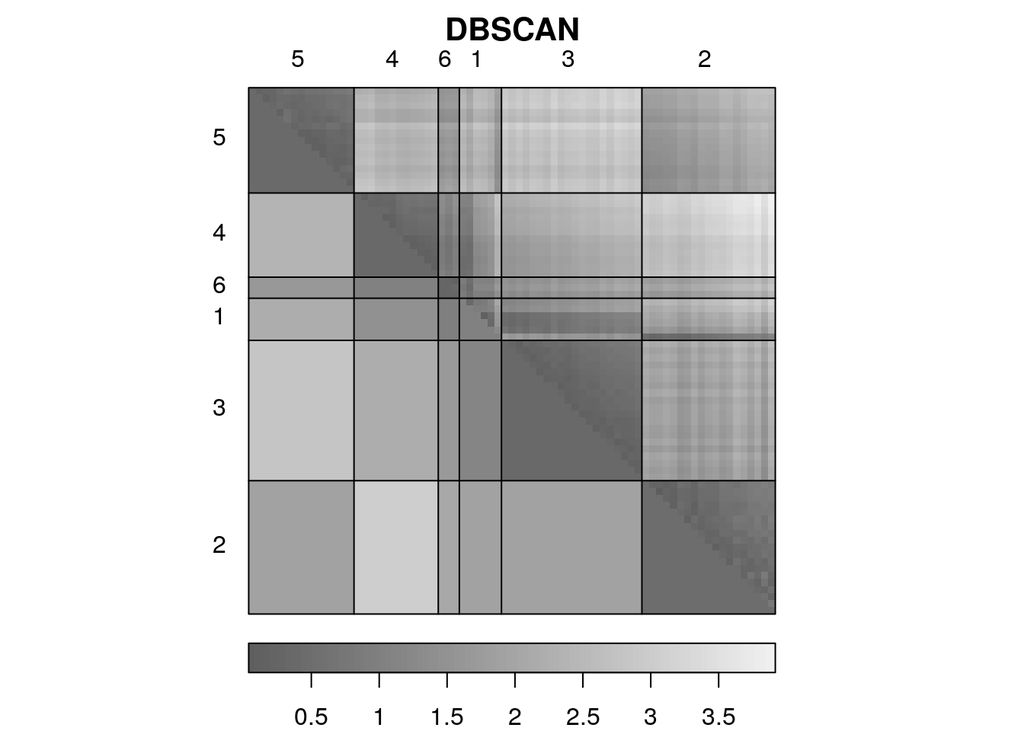

```r
dissplot(d, labels=db$cluster+1, options=list(main="DBSCAN"))
```

Spot the problem data points for DBSCAN (we use +1 so the noise is now cluster #1)

Misspecified k

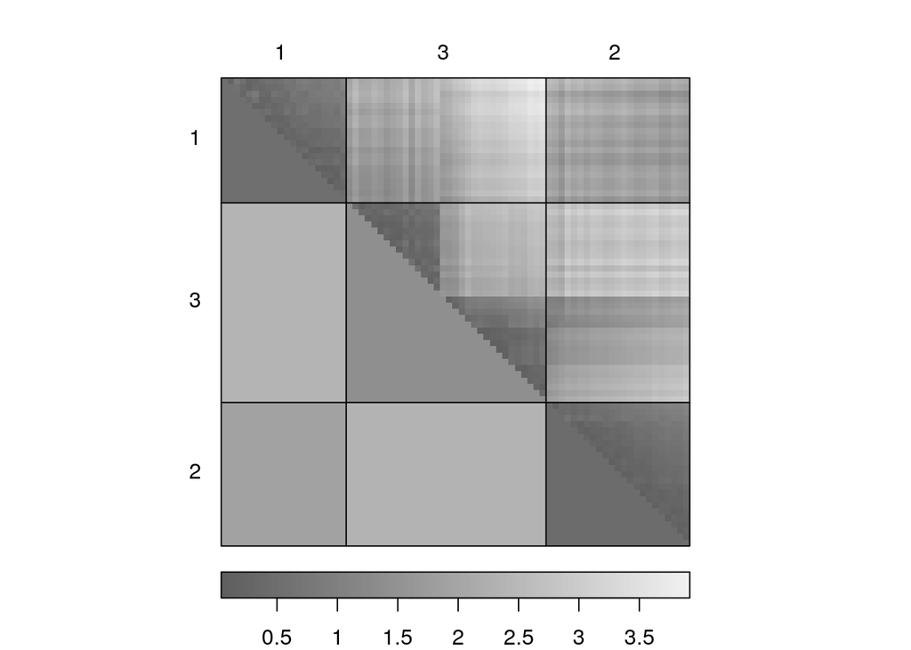

```r
dissplot(d, labels=kmeans(ruspini_scaled, centers=3)$cluster)
```

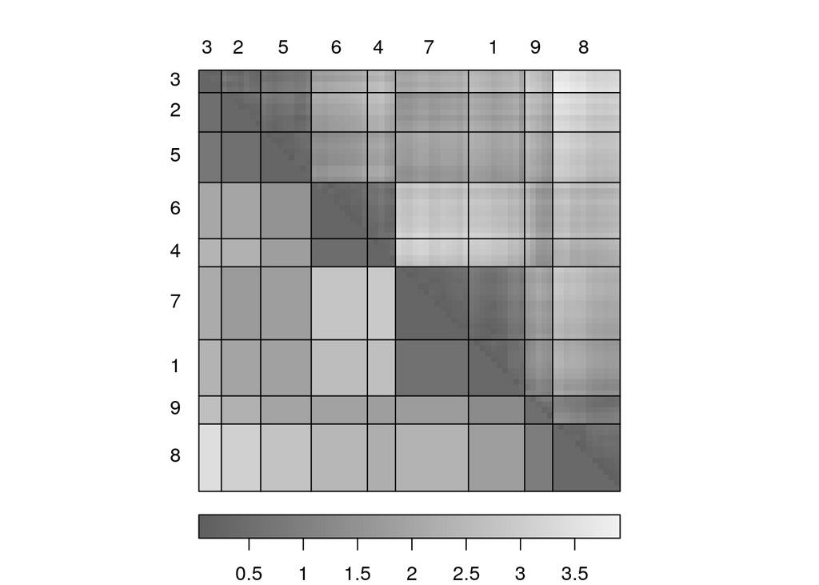

```r
dissplot(d, labels=kmeans(ruspini_scaled, centers=9)$cluster)
```